# R Notebook

This notebook uses Census Bureau Survey of Income and Program Participation (SIPP) data to begin looking at the negative consequences of unequal access to unemployment compensation programs.

```r
library(tidyverse)
library(survey)
library(randplot)
```

## The Problem

The scarring effects of unemployment are well documented. After an involuntary job separation, workers often struggle to find comparable employment opportunties. This results in lost wages that can take as long as a decade to recover to their pre-shock (unemployment spell) trend. Research has found that unemployment scarring effects tend to be worse for minority workers, younger workers, and workers in lower-wage jobs.

The main social protection for unemployed workers in the United States is federal and state unemployment insurance programs. These programs, administered by each state with some funding from the federal government, provide workers who meet certain work or income thresholds in the base period with temporary assistance while unemployed to help them smooth their consumption as they search for a new job. This assistance can be critical to give workers the liquidity they require to conduct thorough job searches and find a job that is comparable or better to their prior employment.

Unfortunately, recent research has shown that takeup and receipt of unemployment insurance (measured in terms of the percent applying for benefits, percent receiving benefits, and the overall replacement ratio) is not equal in ways similar to the overall scarring effects of unemployment. Black workers are much less likely to receive unemployment compensation when laid off and eligible for it than white workers and receive lower benefit amounts on average if they do receive UC. Lower income workers are also less likely to receive UC than their higher income counterparts.

These inequalities are likely to have a strong impact on how lower income and Black workers are able to respond to job losses, with downstream consequences for wealth and income inequality. This project aims to examine the shorter-term mechanisms through which inequal access to UC may contribute to inequality. In short, it will examine the relationship between UC reciept for the unemployed and costly financial behaviors (use of alternative financial services, borrowing against retirement accounts, carrying high-cost debt, defaulting on loans, etc.). Ultimately the project will seek to ‘cost’ the inequality in UC for the system, predict retraining costs for affected workers, and provide policy ideas to increase UI takeup.

## Data

The SIPP was created in 1984 and serves as the major source of data on income and prograrm participation in the United States. It is conducted annually as a series of overlapping panels with monthly data for each respondent.

I started the analysis small, using just year-end data for 2022. This is downloaded using the `lodown` package and read in alongside its replicate weight file.`

```r
sipp_df = readRDS("Data/sipp202212.rds")
```

There is data for 5479 variables, but I am primarily interested in just a subset of variables and demographic covariates. The main variables of interest are if the individual ever had time away from work without pay (ejb1_awop1) and if they ever received UC payments in the sample year (eucany). There are also variables on the type of UC received (government, private, other, pandemic), various demographics including age, race, and sex.

We use the `survey` package to construct estimates fo the variables of interest using the appropriate replication weights.

```r
sipp_design = svrepdesign(data = sipp_df,
                          weights = ~ wpfinwgt,
                          repweights = "repwgt([1-9]+)",
                          type = "Fay",
                          rho = 0.5)
```

Variables on job separations can be combined with income information to create a very rough measure of UC program eligibility. In reality, exact eligibility criteria vary by state and can often be multi-pronged involving meeting either income, time in work, or both types of requirements. To simplify, in order to conduct an initial rough analysis, I code an individual as eligible for UC if they receive income greater than $5,200, which would guarantee that they are eligible for UC in California.

```r
summary(sipp_df$tftotinc)
```

```
   Min. 1st Qu.  Median    Mean 3rd Qu.    Max.
 -22677    2938    6334    9976   11802  377165
```

```r
summary(sipp_df$thtotinc)
```

```
   Min. 1st Qu.  Median    Mean 3rd Qu.    Max.
 -22677    3406    6941   10585   12460  377165
```

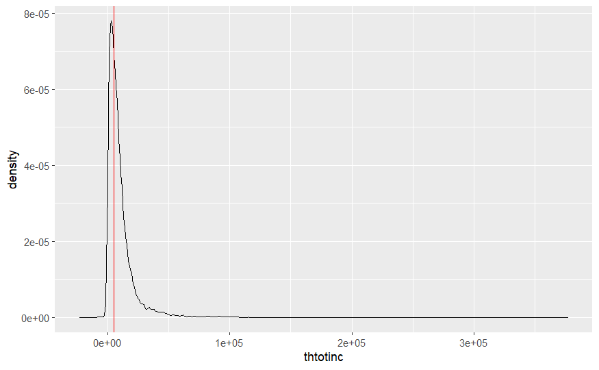

```r
ggplot(sipp_df, aes(x = thtotinc)) + geom_density() + geom_vline(xintercept = 5200, color = 'red')
```

The figure above plots the income distribution for the sample relative to the UC eligibility threshold that I’ve set. As can be seen, this threshold alone rules out a good chunk of the population who would not have worked enough in the year to receive UC if they were laid off in December.

```r
sipp_design = update(sipp_design,
                     state_name = factor(as.numeric(tehc_st),
                                         levels = c(1L, 2L, 4L, 5L, 6L, 8L, 9L, 10L, 11L,
                                                    12L, 13L, 15L, 16L, 17L, 18L, 19L, 20L,
                                                    21L, 22L, 23L, 24L, 25L, 26L, 27L, 28L,
                                                    29L, 30L, 31L, 32L, 33L, 34L, 35L, 36L,
                                                    37L, 38L, 39L, 40L, 41L, 42L, 44L, 45L,
                                                    46L, 47L, 48L, 49L, 50L, 51L, 53L, 54L,
                                                    55L, 56L, 60L, 61L),
                                         labels = c("Alabama", "Alaska", "Arizona", "Arkansas", "California", "Colorado", "Connecticut", "Delaware", "DC", "Florida", "Georgia", "Hawaii", "Idaho", "Illinois", "Indiana", "Iowa", "Kansas", "Kentucky", "Louisiana", "Maine", "Maryland", "Massachusetts", "Michigan", "Minnesota", "Mississippi", "Missouri", "Montana", "Nebraska", "Nevada", "New Hampshire", "New Jersey", "New Mexico", "New York", "North Carolina", "North Dakota", "Ohio", "Oklahoma", "Oregon", "Pennsylvania", "Rhode Island", "South Carolina", "South Dakota", "Tennessee", "Texas", "Utah", "Vermont", "Virginia", "Washington", "West Virginia", "Wisconsin", "Wyoming", "Puerto Rico", "Foreign Country")),
                     unemployed = ifelse(ejb1_awop1==1, 1, 0),
                     receive_ec = ifelse(eucany==1, 1, 0),
                     race = factor(erace,
                                   levels = c(1,2,3,4),
                                   labels = c("White", "Black", "Asian", "Other")),
                     uc_eligible = ifelse(thtotinc>=5200, 1, 0))
```

After establishing UC eligibility and examining disparities in receipt, we can look at the relationship between receiving UC for an unemployed worker and various financial behaviors and measures of financial hardship. Here, I can examine inability to pay utility bills or rent/mortgage payments, receipt of charitable assistance, receiving assistance from family or friends, changing their retirement timing, owing money on a credit card, and other debts.

## Initial Descriptive Statistics

I start by looking at general patterns in unemployment in the sample. Overall, 9% of individuals in the sample reported ever being unemployed in 2022. Black respondents in the sample were slightly more likely to report being unemployed at some point than white respondents.

```r
svymean(~ unemployed, sipp_design, na.rm=T)

svyby(~ unemployed, ~race, sipp_design, svymean, na.rm=T)
```

[output not shown]

In the total sample, 3.8% of individuals received UC payments. Black respondents were also more likely to receive UC, but this could be driven largely by higher overall levels of unemployment.

```r
svymean(~ receive_ec, sipp_design, na.rm=T)

svyby(~ receive_ec, ~race, sipp_design, svymean, na.rm=T)
```

[output not shown]

We can look at just the subset of workers who are unemployed and who we expect to be eligible for UC payments. Now, looking at just this subset, 13.6% of eligible white unemployed workers receive UC payments compared to less than 9% of eligible Black unemployed workers. Overall, these percentages are still much lower than anticipated, indicating that I may not be doing enough to limit the eligible population. Eligible Asian workers in the sample are even less likely to receive UC payments.

```r
sub_sipp_design = subset(sipp_design, unemployed==1 & uc_eligible==1)

ec_receipt = svyby(~ receive_ec, ~race, sub_sipp_design, svymean, na.rm=T)
ec_receipt
```

[output not shown]

We can also plot these points with confidence bands.

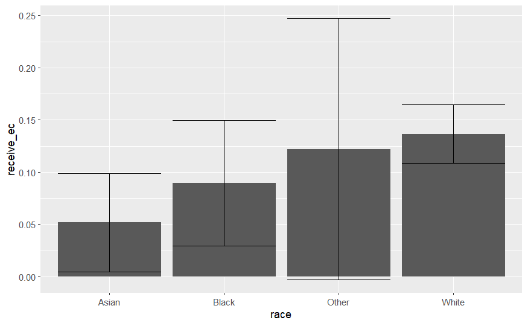